# Workshop on R Data Literacy

The lecture content from a 2-day workshop I delivered for individuals working at the Virginia Department of Environmental Quality tht focused on building a foundation of data analysis using R.

Published

March 4, 2022

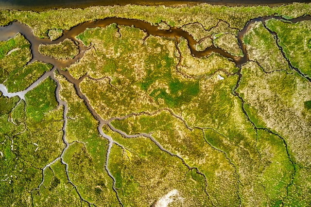

Venti Views Image from Unspalsh

## Workshop Logistics

*When:*

March 7-8, 2022

*Where:*

1111 East Main Street, Richmond Virginia [37.5367, -77.4350](https://www.google.com/maps/place/1111+E+Main+St,+Richmond,+VA+23219/@37.5365814,-77.4372005,17z/data=!3m1!4b1!4m5!3m4!1s0x89b111183eed8707:0x24b3c78b6da63e39!8m2!3d37.5365772!4d-77.4350118)

*Impetus:*

Build internal capacity at for using R as an analysis platform to increase efficiency of data management.

*Instructor:*

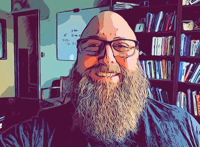

### Introduction to R and RStudio

[figure not shown]

Learning Objectives:  
- Learning about the R environment,  
- Understand differences between coding to the Console versus making scripts,  
- Use a Project to organize code, data, analyses, & narratives,  
- Personalize the RStudio GUI for success.

### Character Data and Basic Function Usage

[figure not shown]

Learning Objectives:  
- Learn about basic function structure,  
- Explore the built-in help system,  
- Practice operations using the fundamental data type `character`,  
- Manipulate data in `vector` formats,  
- Perform textual analyses using the `stringr` library.

[stringr Cheatsheet](https://evoldyn.gitlab.io/evomics-2018/ref-sheets/R_strings.pdf)

### Numeric Data and Data Frames

[figure not shown]

Learning Objectives:  
- Explore numeric data and mathematical operations.  
- Create and manipulate data within `data.frame` objects.

### Basic Data Manipulation - Tidyverse

[figure not shown]

Learning Objectives:  
- Understand data manipulation verbs,  
- Pipe data through several modifier functions to derive inferences,  
- Filter and select subsets of a larger data set,  
- Group and summarize measurements to derive summary parameters

[Data Wrangling Cheatsheet](https://www.rstudio.com/wp-content/uploads/2015/02/data-wrangling-cheatsheet.pdf)

### Non-Character Character Data

[figure not shown]

Learning Objectives:  
- Apply the `mutate` operator to create derived data columns.  
- Demonstrate the use of unordered and ordered factor data.  
- Convert textual representations of dates and times into date objects.  
- Derive temporal inferences from date objects

[forcats Cheatsheet](http://www.flutterbys.com.au/stats/downloads/slides/figure/factors.pdf)

[lubridate Cheatsheet](https://raw.githubusercontent.com/rstudio/cheatsheets/main/lubridate.pdf)

### Visualizing Data - Basic & GGPlot

[figure not shown]

Learning Objectives:  
- Learn about joins to merge data from two or more data.frames. - Develop your first function for consistent data formatting prior to visualization.  
- Understand and implement basic plotting routines provided in `R::graphics`  
- Convert raw data into high-quality graphical output using a variety of `ggplot2` routines.

[visualization Cheatsheet](https://raw.githubusercontent.com/rstudio/cheatsheets/main/data-visualization.pdf)

### Interactive Mapping

[figure not shown]

Learning Objectives:  
- Understand how to create a viable map display.  
- Apply differential tile providers to an interactive map.  
- Create markers on a map representing data found within the data frame.

[leaflet Cheatsheet](https://ugoproto.github.io/ugo_r_doc/pdf/leaflet-cheat-sheet.pdf)

### Markdown

[figure not shown]

Learning Objectives:  
- Understand basic markup to represent common textual components.  
- Insert graphical output (figures, maps, etc) into a markdown document.  
- Inject components of statistical inferences into the text of a markdown document.

[markdown Cheatsheet](https://raw.githubusercontent.com/rstudio/cheatsheets/main/rmarkdown.pdf)